# R Notebook

sturgesovo pravidlo

```r
#install.packages("corrplot")
#install.packages("car")
```

```r
library(dplyr)
data <- read.csv(".\\dataset\\data.csv")
```

ZDROJ:https://www.kaggle.com/yamaerenay/spotify-dataset-19212020-160k-tracks

```r
glimpse(data)
```

```
Rows: 174,389
Columns: 19
$ acousticness     <dbl> 9.91e-01, 6.43e-01, 9.93e-01, 1.73e-04, 2.95e-01, 9.96e-01, 9.92e-01, 9.96e-01, 9.96e~
$ artists          <chr> "['Mamie Smith']", "[\"Screamin' Jay Hawkins\"]", "['Mamie Smith']", "['Oscar Velazqu~
$ danceability     <dbl> 0.598, 0.852, 0.647, 0.730, 0.704, 0.424, 0.782, 0.474, 0.469, 0.571, 0.688, 0.579, 0~
$ duration_ms      <int> 168333, 150200, 163827, 422087, 165224, 198627, 195200, 186173, 146840, 476304, 15006~
$ energy           <dbl> 0.2240, 0.5170, 0.1860, 0.7980, 0.7070, 0.2450, 0.0573, 0.2390, 0.2380, 0.7530, 0.220~
$ explicit         <int> 0, 0, 0, 0, 1, 0, 0, 0, 0, 0, 0, 0, 0, 0, 0, 0, 0, 0, 0, 0, 0, 0, 0, 0, 0, 0, 0, 0, 1~
$ id               <chr> "0cS0A1fUEUd1EW3FcF8AEI", "0hbkKFIJm7Z05H8Zl9w30f", "11m7laMUgmOKqI3oYzuhne", "19Lc5S~
$ instrumentalness <dbl> 5.22e-04, 2.64e-02, 1.76e-05, 8.01e-01, 2.46e-04, 7.99e-01, 1.61e-06, 1.86e-01, 9.60e~
$ key              <int> 5, 5, 0, 2, 10, 5, 5, 9, 8, 8, 6, 10, 1, 1, 2, 2, 11, 1, 2, 5, 9, 2, 1, 10, 2, 1, 8, ~
$ liveness         <dbl> 0.3790, 0.0809, 0.5190, 0.1280, 0.4020, 0.2350, 0.1760, 0.1950, 0.1490, 0.0920, 0.262~
$ loudness         <dbl> -12.628, -7.261, -12.098, -7.311, -6.036, -11.470, -12.453, -9.712, -18.717, -6.943, ~
$ mode             <int> 0, 0, 1, 1, 0, 1, 1, 1, 1, 1, 0, 1, 1, 1, 1, 1, 1, 1, 1, 0, 1, 1, 1, 0, 1, 1, 0, 1, 1~
$ name             <chr> "Keep A Song In Your Soul", "I Put A Spell On You", "Golfing Papa", "True House Music~
$ popularity       <int> 12, 7, 4, 17, 2, 9, 5, 0, 0, 0, 0, 0, 0, 0, 0, 0, 0, 0, 0, 0, 8, 0, 0, 1, 3, 0, 0, 0,~
$ release_date     <chr> "1920", "1920-01-05", "1920", "1920-01-01", "1920-10-01", "1920", "1920", "1920", "19~
$ speechiness      <dbl> 0.0936, 0.0534, 0.1740, 0.0425, 0.0768, 0.0397, 0.0592, 0.0289, 0.0741, 0.0446, 0.845~
$ tempo            <dbl> 149.976, 86.889, 97.600, 127.997, 122.076, 103.870, 85.652, 78.784, 130.060, 126.993,~
$ valence          <dbl> 0.6340, 0.9500, 0.6890, 0.0422, 0.2990, 0.4770, 0.4870, 0.3660, 0.6210, 0.1190, 0.414~
$ year             <int> 1920, 1920, 1920, 1920, 1920, 1920, 1920, 1920, 1920, 1920, 1920, 1920, 1920, 1920, 1~
```

```r
unique(is.na(data))
```

```
     acousticness artists danceability duration_ms energy explicit    id instrumentalness   key liveness
[1,]        FALSE   FALSE        FALSE       FALSE  FALSE    FALSE FALSE            FALSE FALSE    FALSE
     loudness  mode  name popularity release_date speechiness tempo valence  year
[1,]    FALSE FALSE FALSE      FALSE        FALSE       FALSE FALSE   FALSE FALSE
```

```r
length(data$name)
```

```
[1] 174389
```

```r
length(unique(data$name))
```

```
[1] 137013
```

```r
n_occur <- data.frame(table(data$name))
n_occur[n_occur$Freq > 1,]
```

|  | Var1 | Freq |
| --- | --- | --- |
| 4 | '39 - Remastered 2011 | 2 |
| 10 | '97 Bonnie & Clyde | 2 |
| 23 | 'A vucchella | 2 |
| 30 | 'Cause I Love You | 3 |
| 32 | 'Cross the Breeze (Album Version) | 2 |
| 34 | 'Deed I Do | 6 |
| 50 | 'O sole mio | 2 |
| 60 | 'Round About Midnight | 2 |
| 63 | 'Round Midnight | 21 |
| 68 | 'Round Midnight - Rudy Van Gelder Remaster | 2 |

[output cut: 990 more lines]

Dataset neobsahuje ziadne NaN hodnoty.

```r
rel_date_data = data.frame(chr=apply(data,2,nchar)[,15])
rel_date_data %>% group_by(chr) %>% summarize(count=n())
```

| chr | count |
| --- | --- |
| 4 | 50819 |
| 7 | 1586 |
| 10 | 121984 |

Jedina nekonzistencia sa nachadza v stlpci release_date.Navyse sme pri preverovani teorie, ze stare pesnicky nie su popularne narazili na modernu elektronicku hudbu , co sme aj neskor overili z inych zdrojov(wikipedia, datum umrtia spevaka, youtube release na oficialnom kanali) a zistili sme ze chybne udaje pochadzaju priamo zo spotify. Nazvy autorov a piesni su obacas necitatelne zrejme kvoli pouzitiu inej abecedy. Kedze sa chceme zamerat na popularitu piesni a vplyv numerickych hudobnych atributov na nu, tak dataset mozeme pouzit a nazvy nemusime opravovat.

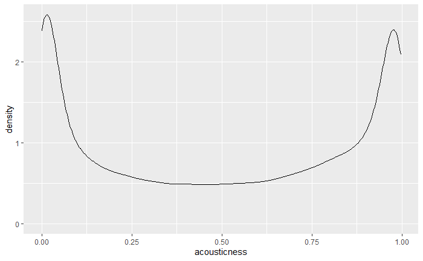

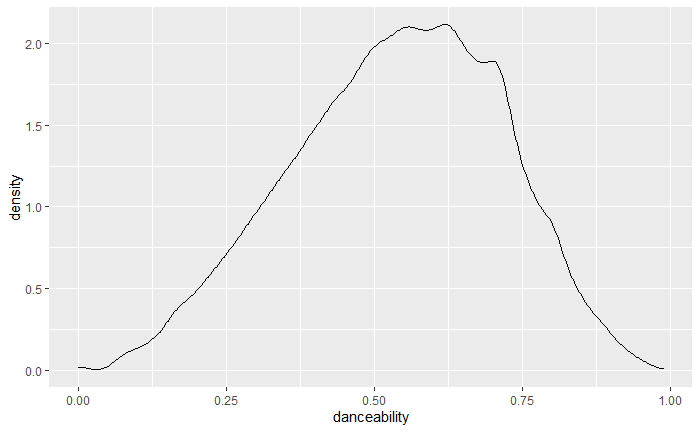

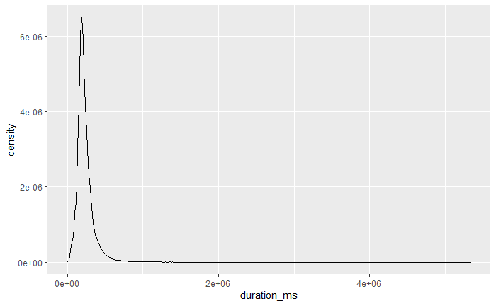

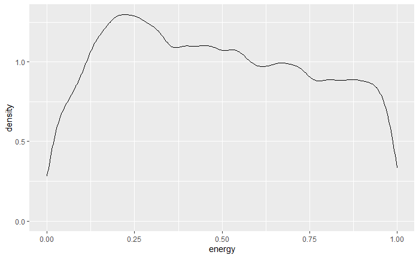

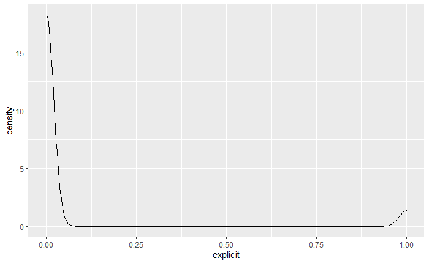

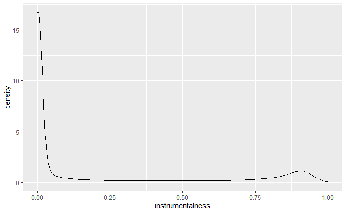

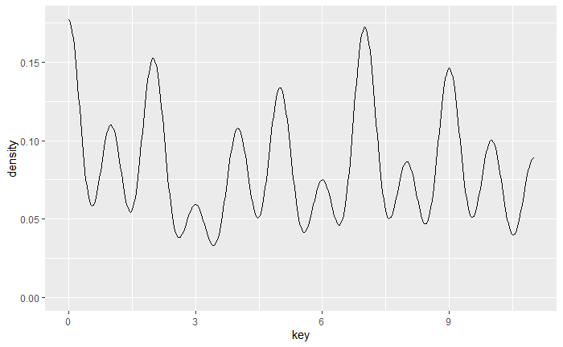

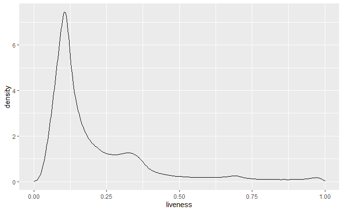

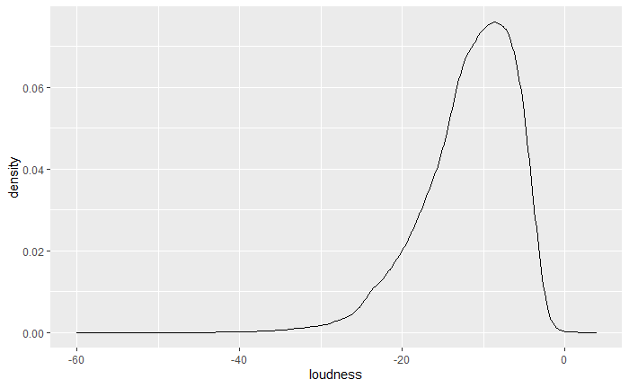

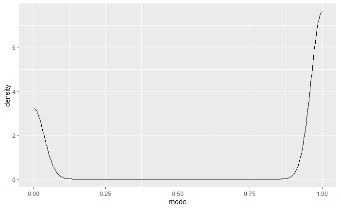

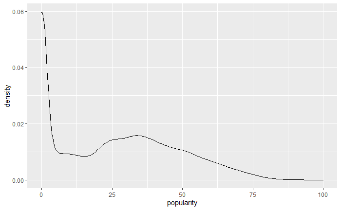

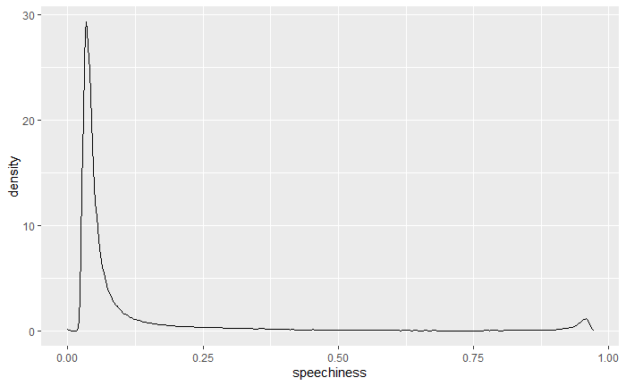

[3 more figures not shown]

```r
library(tidyverse)
my_plots <- lapply(names(data), function(var_x){
  p <-
    ggplot(data) +
    aes_string(var_x)

  if(is.numeric(data[[var_x]])) {
    p <- p + geom_density()
    plot(p)
  }

})
```

```r
num_data <- subset(data, select = -year) %>% select(where(is.numeric))
```

```r
#data %>%
#  group_by(year) %>%
#  summarise(mean_energy = mean(energy, na.rm = TRUE), mean_loudness = mean(loudness, na.rm = TRUE), mean_popularity = mean(popularity, na.rm = TRUE))

#src: https://www.tutorialspoint.com/r/r_mean_median_mode.htm
getmode <- function(v) {
   uniqv <- unique(v)
   uniqv[which.max(tabulate(match(v, uniqv)))]
}

maxVal <- function(dataset) sapply(dataset, max, na.rm = TRUE)
minVal <- function(dataset) sapply(dataset, min, na.rm = TRUE)
meanVal <- function(dataset) sapply(dataset, mean, na.rm = TRUE)
standDev <- function(dataset) sapply(dataset, sd, na.rm = TRUE)
medVal <- function(dataset) sapply(dataset, median, na.rm = TRUE)
modVal <- function(dataset) sapply(dataset, getmode)
varVal <- function(dataset) sapply(dataset, var, na.rm = TRUE)
#boxplot
#sapply(num_data, function(x) boxplot(x))

maxVal(data)
```

```
            acousticness                  artists             danceability              duration_ms
                 "0.996"   "[\"Y'Anna Crawley\"]"                  "0.988"                "5338302"
                  energy                 explicit                       id         instrumentalness
                     "1"                      "1" "7zZvgaapV63jpzCO1dmu5G"                      "1"
                     key                 liveness                 loudness                     mode
                    "11"                      "1"                  "3.855"                      "1"
                    name               popularity             release_date              speechiness
                    "ZZ"                    "100"             "2021-01-23"                  "0.971"
                   tempo                  valence                     year
               "243.507"                      "1"                   "2021"
```

```r
minVal(data)
```

```
            acousticness                  artists             danceability              duration_ms
                     "0"               "['-Sd-']"                      "0"                   "4937"
                  energy                 explicit                       id         instrumentalness
                     "0"                      "0" "000G1xMMuwxNHmwVsBdtj1"                      "0"
                     key                 liveness                 loudness                     mode
                     "0"                      "0"                    "-60"                      "0"
                    name               popularity             release_date              speechiness
          "' Cello Song"                      "0"                   "1920"                      "0"
                   tempo                  valence                     year
                     "0"                      "0"                   "1920"
```

```r
meanVal(data)
```

```
argument is not numeric or logical: returning NAargument is not numeric or logical: returning NAargument is not numeric or logical: returning NAargument is not numeric or logical: returning NA
```

```
    acousticness          artists     danceability      duration_ms           energy         explicit
    4.992285e-01               NA     5.367576e-01     2.328100e+05     4.827208e-01     6.813503e-02
              id instrumentalness              key         liveness         loudness             mode
              NA     1.972520e-01     5.205305e+00     2.111231e-01    -1.175086e+01     7.023838e-01
            name       popularity     release_date      speechiness            tempo          valence
              NA     2.569338e+01               NA     1.057292e-01     1.170065e+02     5.245327e-01
            year
    1.977062e+03
```

```r
standDev(data)
```

```
NAs introduced by coercionNAs introduced by coercionNAs introduced by coercionNAs introduced by coercion
```

```
    acousticness          artists     danceability      duration_ms           energy         explicit
    3.799358e-01               NA     1.760253e-01     1.483958e+05     2.726855e-01     2.519782e-01
              id instrumentalness              key         liveness         loudness             mode
              NA     3.345737e-01     3.518292e+00     1.804927e-01     5.691591e+00     4.572111e-01
            name       popularity     release_date      speechiness            tempo          valence
             NaN     2.187274e+01     2.174601e+01     1.822602e-01     3.025418e+01     2.644768e-01
            year
    2.690795e+01
```

```r
medVal(data)
```

```
               acousticness                     artists                danceability                 duration_ms
                    "0.517"            "['Kejsi Tola']"                     "0.548"                    "205787"
                     energy                    explicit                          id            instrumentalness
                    "0.465"                         "0"    "3oXZc7JQUfqs29lpyQFny6"                  "0.000524"
                        key                    liveness                    loudness                        mode
                        "5"                     "0.138"                   "-10.836"                         "1"
                       name                  popularity                release_date                 speechiness
"Let's Turn Back the Years"                        "25"                "1977-09-13"                    "0.0455"
                      tempo                     valence                        year
                  "115.816"                     "0.536"                      "1977"
```

```r
modVal(data)
```

```
                  acousticness                        artists                   danceability
                       "0.995" "['Tadeusz Dolega Mostowicz']"                        "0.565"
                   duration_ms                         energy                       explicit
                      "180000"                        "0.195"                            "0"
                            id               instrumentalness                            key
      "0UsmyJDsst2xhX1ZiFF3JW"                            "0"                            "0"
                      liveness                       loudness                           mode
                       "0.111"                       "-7.578"                            "1"
                          name                     popularity                   release_date
             "White Christmas"                            "0"                         "1945"
                   speechiness                          tempo                        valence
                      "0.0337"                            "0"                        "0.961"
                          year
                        "2020"
```

```r
varVal(data)
```

```
NAs introduced by coercionNAs introduced by coercionNAs introduced by coercionNAs introduced by coercion
```

```
    acousticness          artists     danceability      duration_ms           energy         explicit
    1.443512e-01               NA     3.098489e-02     2.202131e+10     7.435737e-02     6.349301e-02
              id instrumentalness              key         liveness         loudness             mode
              NA     1.119396e-01     1.237838e+01     3.257762e-02     3.239421e+01     2.090420e-01
            name       popularity     release_date      speechiness            tempo          valence
             NaN     4.784167e+02     4.728891e+02     3.321877e-02     9.153153e+02     6.994798e-02
            year
    7.240378e+02
```

```
[1] 759 846
```

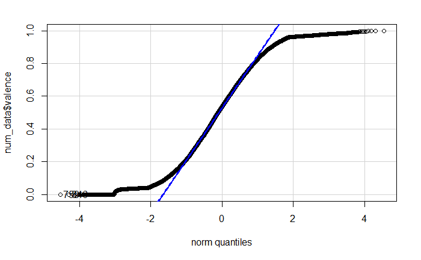

```r
library(car)
qqPlot(num_data$valence)
```

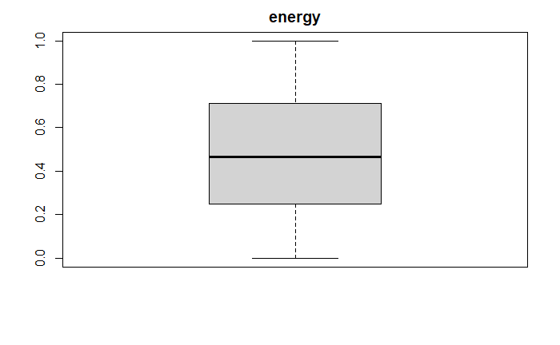

```r
boxplot(num_data$energy, main="energy")
```

```r
nums <- unlist(lapply(data, is.numeric))
#data[ , nums]

colMeans(data[ , nums], na.rm = FALSE)
```

```
    acousticness     danceability      duration_ms           energy         explicit instrumentalness
    4.992285e-01     5.367576e-01     2.328100e+05     4.827208e-01     6.813503e-02     1.972520e-01
             key         liveness         loudness             mode       popularity      speechiness
    5.205305e+00     2.111231e-01    -1.175086e+01     7.023838e-01     2.569338e+01     1.057292e-01
           tempo          valence             year
    1.170065e+02     5.245327e-01     1.977062e+03
```

```r
apply(data[ , nums],2,median)
```

```
    acousticness     danceability      duration_ms           energy         explicit instrumentalness
     5.17000e-01      5.48000e-01      2.05787e+05      4.65000e-01      0.00000e+00      5.24000e-04
             key         liveness         loudness             mode       popularity      speechiness
     5.00000e+00      1.38000e-01     -1.08360e+01      1.00000e+00      2.50000e+01      4.55000e-02
           tempo          valence             year
     1.15816e+02      5.36000e-01      1.97700e+03
```

```r
library(corrr)
data[ , nums] %>% correlate() %>% focus(popularity)
```

```
Correlation method: 'pearson'
Missing treated using: 'pairwise.complete.obs'
```

| term | popularity |
| --- | --- |
| acousticness | -0.396744051 |
| danceability | 0.123745802 |
| duration_ms | 0.024717408 |
| energy | 0.328938616 |
| explicit | 0.152545482 |
| instrumentalness | -0.300625111 |
| key | 0.001951113 |
| liveness | -0.078959117 |
| loudness | 0.337194109 |
| mode | 0.007652217 |

[output cut: 4 more lines]

```r
glimpse(num_data)
```

```
Rows: 174,389
Columns: 14
$ acousticness     <dbl> 9.91e-01, 6.43e-01, 9.93e-01, 1.73e-04, 2.95e-01, 9.96e-01, 9.92e-01, 9.96e-01, 9.96e~
$ danceability     <dbl> 0.598, 0.852, 0.647, 0.730, 0.704, 0.424, 0.782, 0.474, 0.469, 0.571, 0.688, 0.579, 0~
$ duration_ms      <int> 168333, 150200, 163827, 422087, 165224, 198627, 195200, 186173, 146840, 476304, 15006~
$ energy           <dbl> 0.2240, 0.5170, 0.1860, 0.7980, 0.7070, 0.2450, 0.0573, 0.2390, 0.2380, 0.7530, 0.220~
$ explicit         <int> 0, 0, 0, 0, 1, 0, 0, 0, 0, 0, 0, 0, 0, 0, 0, 0, 0, 0, 0, 0, 0, 0, 0, 0, 0, 0, 0, 0, 1~
$ instrumentalness <dbl> 5.22e-04, 2.64e-02, 1.76e-05, 8.01e-01, 2.46e-04, 7.99e-01, 1.61e-06, 1.86e-01, 9.60e~
$ key              <int> 5, 5, 0, 2, 10, 5, 5, 9, 8, 8, 6, 10, 1, 1, 2, 2, 11, 1, 2, 5, 9, 2, 1, 10, 2, 1, 8, ~
$ liveness         <dbl> 0.3790, 0.0809, 0.5190, 0.1280, 0.4020, 0.2350, 0.1760, 0.1950, 0.1490, 0.0920, 0.262~
$ loudness         <dbl> -12.628, -7.261, -12.098, -7.311, -6.036, -11.470, -12.453, -9.712, -18.717, -6.943, ~
$ mode             <int> 0, 0, 1, 1, 0, 1, 1, 1, 1, 1, 0, 1, 1, 1, 1, 1, 1, 1, 1, 0, 1, 1, 1, 0, 1, 1, 0, 1, 1~
$ popularity       <int> 12, 7, 4, 17, 2, 9, 5, 0, 0, 0, 0, 0, 0, 0, 0, 0, 0, 0, 0, 0, 8, 0, 0, 1, 3, 0, 0, 0,~
$ speechiness      <dbl> 0.0936, 0.0534, 0.1740, 0.0425, 0.0768, 0.0397, 0.0592, 0.0289, 0.0741, 0.0446, 0.845~
$ tempo            <dbl> 149.976, 86.889, 97.600, 127.997, 122.076, 103.870, 85.652, 78.784, 130.060, 126.993,~
$ valence          <dbl> 0.6340, 0.9500, 0.6890, 0.0422, 0.2990, 0.4770, 0.4870, 0.3660, 0.6210, 0.1190, 0.414~
```

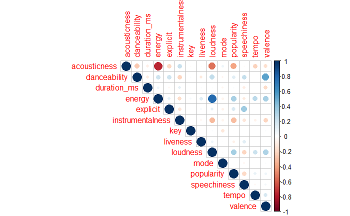

```r
library(corrplot)
corrplot(cor(num_data),type="upper")
```

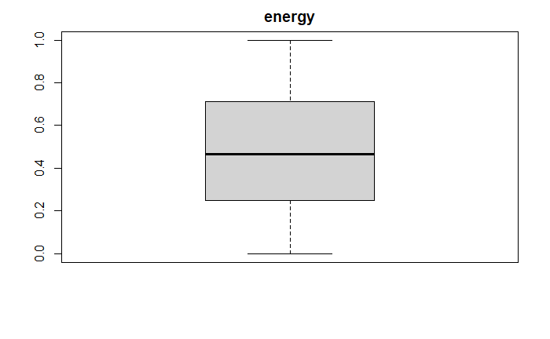

```r
boxplot(num_data$energy, main="energy")
```

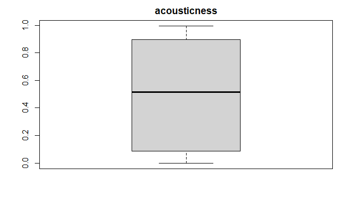

```r
boxplot(num_data$acousticness, main="acousticness")
```

```
[1] -26.021   3.367
```

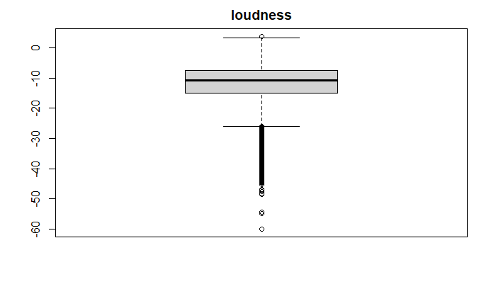

```r
boxplot(num_data$loudness, main="loudness")$stats[c(1, 5), ]
```

```
[1] 0.00 0.63
```

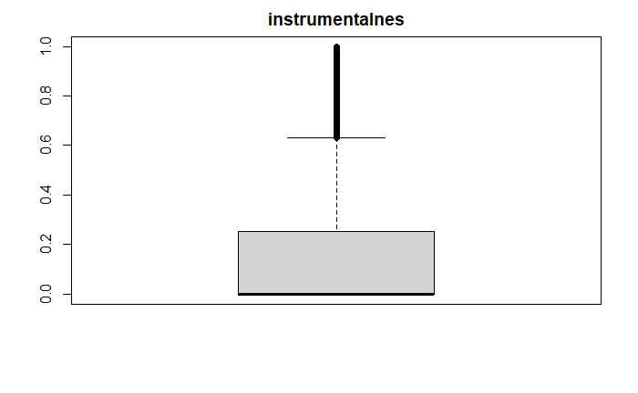

```r
boxplot(num_data$instrumentalnes, main="instrumentalnes")$stats[c(1, 5), ]
```

```
[1]  17000 415093
```

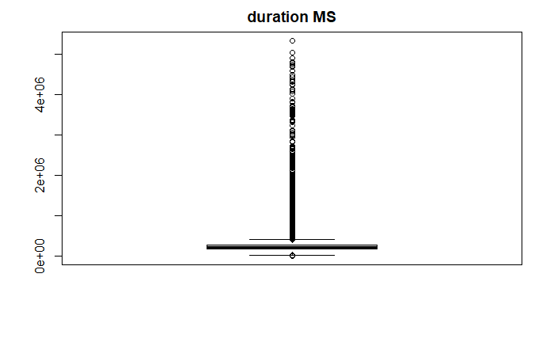

```r
boxplot(num_data$duration_ms, main="duration MS")$stats[c(1, 5), ]
```

```r
#value of whiskers later used for threshold
```

Aby sme si ukázali tvar distribúcie, stredné hodnoty a variabilitu nad atribútmi, na ktoré sme sa chceli zamerať(korelujúce s popularitou) vykreslili sme si ich boxploty. Ďalej sme pomocou thresholdu odstránili príliš krátke a príliš dlhé nahrávky, čím sme odstránili outlierov pozostávajúcich z dlhých mixov, audiokníh a pod. Thresholdové hodnoty sme získali z whiskers boxplotu a ostali nam tak pesničky medzi 17 sekund a cca 7 min. Pri ostatných sme outlierov neodstranovali pretože nevieme zaručiť, že outlierové hodnoty by nám neboli prospešné alebo neboli správne zadané alebo odmerané.

```r
num_data_thr <- num_data[num_data$duration_ms>17000 & num_data$duration_ms<415093,]
summary(num_data)
```

```
  acousticness     danceability     duration_ms          energy          explicit       instrumentalness
 Min.   :0.0000   Min.   :0.0000   Min.   :   4937   Min.   :0.0000   Min.   :0.00000   Min.   :0.000000
 1st Qu.:0.0877   1st Qu.:0.4140   1st Qu.: 166133   1st Qu.:0.2490   1st Qu.:0.00000   1st Qu.:0.000000
 Median :0.5170   Median :0.5480   Median : 205787   Median :0.4650   Median :0.00000   Median :0.000524
 Mean   :0.4992   Mean   :0.5368   Mean   : 232810   Mean   :0.4827   Mean   :0.06814   Mean   :0.197252
 3rd Qu.:0.8950   3rd Qu.:0.6690   3rd Qu.: 265720   3rd Qu.:0.7110   3rd Qu.:0.00000   3rd Qu.:0.252000
 Max.   :0.9960   Max.   :0.9880   Max.   :5338302   Max.   :1.0000   Max.   :1.00000   Max.   :1.000000
      key            liveness         loudness            mode          popularity      speechiness
 Min.   : 0.000   Min.   :0.0000   Min.   :-60.000   Min.   :0.0000   Min.   :  0.00   Min.   :0.0000
 1st Qu.: 2.000   1st Qu.:0.0992   1st Qu.:-14.908   1st Qu.:0.0000   1st Qu.:  1.00   1st Qu.:0.0352
 Median : 5.000   Median :0.1380   Median :-10.836   Median :1.0000   Median : 25.00   Median :0.0455
 Mean   : 5.205   Mean   :0.2111   Mean   :-11.751   Mean   :0.7024   Mean   : 25.69   Mean   :0.1057
 3rd Qu.: 8.000   3rd Qu.:0.2700   3rd Qu.: -7.499   3rd Qu.:1.0000   3rd Qu.: 42.00   3rd Qu.:0.0763
 Max.   :11.000   Max.   :1.0000   Max.   :  3.855   Max.   :1.0000   Max.   :100.00   Max.   :0.9710
     tempo           valence
 Min.   :  0.00   Min.   :0.0000
 1st Qu.: 93.93   1st Qu.:0.3110
 Median :115.82   Median :0.5360
 Mean   :117.01   Mean   :0.5245
 3rd Qu.:135.01   3rd Qu.:0.7430
 Max.   :243.51   Max.   :1.0000
```

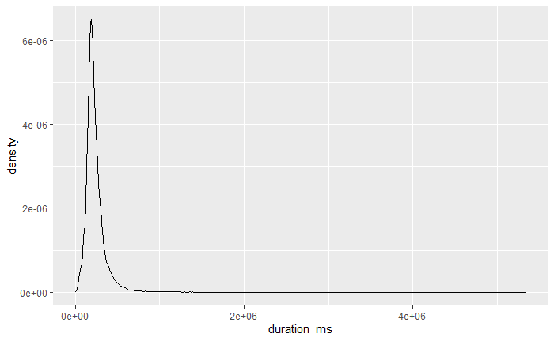

```r
p <-
    ggplot(num_data) +
    aes_string("duration_ms")
    p <- p + geom_density()
    plot(p)
```

```r
length(num_data)
```

```
[1] 14
```

```r
print(str(length(num_data$duration_ms)), str(length(num_data_thr$duration_ms)))
```

```
 int 174389
 int 164332
NULL
```

```r
print(str(length(num_data$duration_ms)-length(num_data_thr$duration_ms)))
```

```
 int 10057
NULL
```

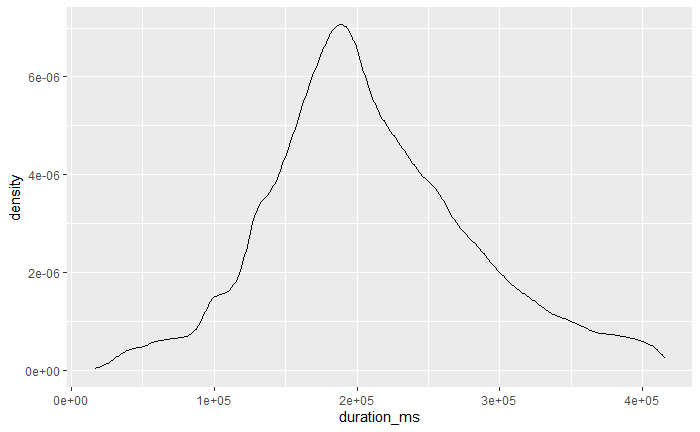

```r
p <-
    ggplot(num_data_thr) +
    aes_string("duration_ms")
    p <- p + geom_density()
    plot(p)
```

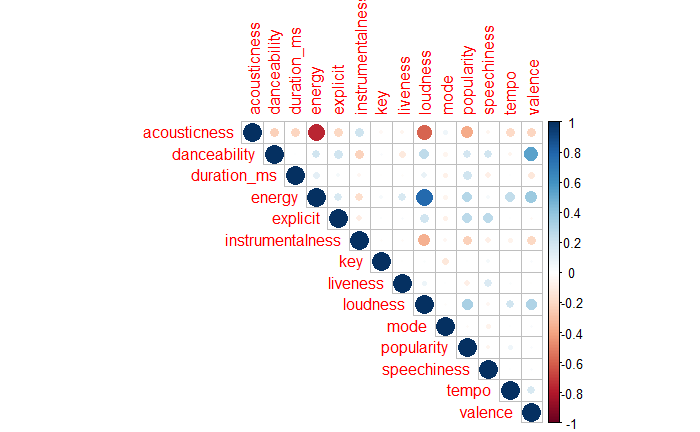

```r
num_data_thrPop <- num_data_thr[num_data_thr$popularity>0,]
corrplot(cor(num_data_thrPop),type="upper")
```

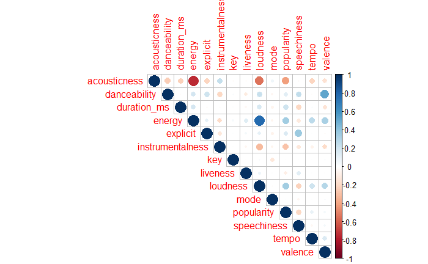

```r
corrplot(cor(num_data_thr),type="upper")
```

```r
#t.test(rnorm(num_data$energy), rnorm(num_data$popularity))
```

V rámci experimentov sme skúsili odstrániť dáta, ktoré mali zaznamenanú nulovú popularitu s tým, že sme chceli pozrieť výlučne na nahrávky s nenulovou popularitou a porovnať aká bude ich korelácia. Zamerali sme sa znova hlavne na korelácie medzi popularitou a zvyškom a zmeny boli minimálne čo teda znamená, že môžme nechať všetky nakolko by nám zameranie sa na nenulové nijako nepomohlo.

```r
dt = sort(sample(nrow(num_data_thr), nrow(num_data_thr)*.8))
train<-num_data_thr[dt,]
test<-num_data_thr[-dt,]
```

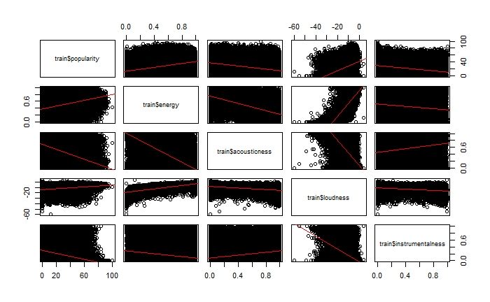

```r
modelPopEn = lm(popularity~energy, data = train)
modelPopAc = lm(popularity~acousticness, data = train)
modelPopLo = lm(popularity~loudness, data = train)
modelPopIns = lm(popularity~instrumentalness, data = train)
pairs(train$popularity ~ train$energy + train$acousticness + train$loudness + train$instrumentalness, panel=function(x,y){
  points(x,y)
  abline(lm(y~x), col='red')})
```

```r
modelPop4 = lm(train$popularity~train$energy + train$acousticness + train$loudness + train$instrumentalness)
```

```r
summary(modelPopEn)#ok
```

```
Call:
lm(formula = popularity ~ energy, data = train)

Residuals:
    Min      1Q  Median      3Q     Max
-40.381 -17.102  -1.054  15.177  75.175

Coefficients:
            Estimate Std. Error t value Pr(>|t|)
(Intercept)  12.7996     0.1165   109.9   <2e-16 ***
energy       27.5814     0.2098   131.5   <2e-16 ***
---
Signif. codes:  0 ‘***’ 0.001 ‘**’ 0.01 ‘*’ 0.05 ‘.’ 0.1 ‘ ’ 1

Residual standard error: 20.65 on 131463 degrees of freedom
Multiple R-squared:  0.1162,    Adjusted R-squared:  0.1162
F-statistic: 1.729e+04 on 1 and 131463 DF,  p-value: < 2.2e-16
```

```r
summary(modelPopAc)#ok ale zly vplyv
```

```
Call:
lm(formula = popularity ~ acousticness, data = train)

Residuals:
    Min      1Q  Median      3Q     Max
-38.044 -14.467  -1.399  14.325  79.127

Coefficients:
              Estimate Std. Error t value Pr(>|t|)
(Intercept)   38.04393    0.09131   416.6   <2e-16 ***
acousticness -23.81511    0.14578  -163.4   <2e-16 ***
---
Signif. codes:  0 ‘***’ 0.001 ‘**’ 0.01 ‘*’ 0.05 ‘.’ 0.1 ‘ ’ 1

Residual standard error: 20.02 on 131463 degrees of freedom
Multiple R-squared:  0.1687,    Adjusted R-squared:  0.1687
F-statistic: 2.669e+04 on 1 and 131463 DF,  p-value: < 2.2e-16
```

```r
summary(modelPopLo)#OK
```

```
Call:
lm(formula = popularity ~ loudness, data = train)

Residuals:
    Min      1Q  Median      3Q     Max
-46.863 -17.536   0.127  15.359  89.309

Coefficients:
            Estimate Std. Error t value Pr(>|t|)
(Intercept) 41.71398    0.13007   320.7   <2e-16 ***
loudness     1.33559    0.01005   132.9   <2e-16 ***
---
Signif. codes:  0 ‘***’ 0.001 ‘**’ 0.01 ‘*’ 0.05 ‘.’ 0.1 ‘ ’ 1

Residual standard error: 20.62 on 131463 degrees of freedom
Multiple R-squared:  0.1185,    Adjusted R-squared:  0.1185
F-statistic: 1.767e+04 on 1 and 131463 DF,  p-value: < 2.2e-16
```

```r
summary(modelPopIns)#ok ale zly vplyv
```

```
Call:
lm(formula = popularity ~ instrumentalness, data = train)

Residuals:
    Min      1Q  Median      3Q     Max
-29.718 -16.718  -0.718  15.836  73.682

Coefficients:
                  Estimate Std. Error t value Pr(>|t|)
(Intercept)       29.71823    0.06654   446.6   <2e-16 ***
instrumentalness -19.40029    0.17798  -109.0   <2e-16 ***
---
Signif. codes:  0 ‘***’ 0.001 ‘**’ 0.01 ‘*’ 0.05 ‘.’ 0.1 ‘ ’ 1

Residual standard error: 21.03 on 131463 degrees of freedom
Multiple R-squared:  0.08289,   Adjusted R-squared:  0.08288
F-statistic: 1.188e+04 on 1 and 131463 DF,  p-value: < 2.2e-16
```

```r
summary(modelPop4)
```

```
Call:
lm(formula = train$popularity ~ train$energy + train$acousticness +
    train$loudness + train$instrumentalness)

Residuals:
    Min      1Q  Median      3Q     Max
-42.725 -14.604  -1.169  13.660  82.657

Coefficients:
                        Estimate Std. Error t value Pr(>|t|)
(Intercept)             47.29562    0.40477  116.84   <2e-16 ***
train$energy            -4.79364    0.40674  -11.79   <2e-16 ***
train$acousticness     -19.11118    0.21702  -88.06   <2e-16 ***
train$loudness           0.61497    0.01585   38.79   <2e-16 ***
train$instrumentalness -11.54932    0.17732  -65.13   <2e-16 ***
---
Signif. codes:  0 ‘***’ 0.001 ‘**’ 0.01 ‘*’ 0.05 ‘.’ 0.1 ‘ ’ 1

Residual standard error: 19.41 on 131460 degrees of freedom
Multiple R-squared:  0.2191,    Adjusted R-squared:  0.2191
F-statistic:  9222 on 4 and 131460 DF,  p-value: < 2.2e-16
```

Zaroveň vidime, že chyba je približne na úrovni od 19.5 do 21 čo v našom prípade znamená taktiež percentuálna chyba kedže popularitu máme v intervale od 0 do 100. Preto sme sa rozhodli vyskúšať aj kvadraticku regresiu.

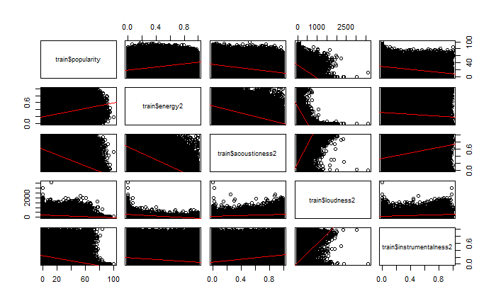

```r
train$energy2 <- train$energy^2
train$acousticness2 <- train$acousticness^2
train$loudness2 <- train$loudness^2
train$instrumentalness2 <- train$instrumentalness^2

modelQPopEn = lm(popularity~energy+energy2, data = train)
modelQPopAc = lm(popularity~acousticness+acousticness2, data = train)
modelQPopLo = lm(popularity~loudness+loudness2, data = train)
modelQPopIns = lm(popularity~instrumentalness+instrumentalness2, data = train)
pairs(train$popularity ~ train$energy2 + train$acousticness2 + train$loudness2 + train$instrumentalness2, panel=function(x,y){
  points(x,y)
  abline(lm(y~x), col='red')})
```

```r
summary(modelQPopEn)#ok
```

```
Call:
lm(formula = popularity ~ energy + energy2, data = train)

Residuals:
   Min     1Q Median     3Q    Max
-34.49 -16.42  -1.13  15.01  77.85

Coefficients:
            Estimate Std. Error t value Pr(>|t|)
(Intercept)   5.9257     0.1878   31.56   <2e-16 ***
energy       66.1599     0.8564   77.26   <2e-16 ***
energy2     -38.3145     0.8250  -46.44   <2e-16 ***
---
Signif. codes:  0 ‘***’ 0.001 ‘**’ 0.01 ‘*’ 0.05 ‘.’ 0.1 ‘ ’ 1

Residual standard error: 20.48 on 131462 degrees of freedom
Multiple R-squared:  0.1305,    Adjusted R-squared:  0.1305
F-statistic:  9865 on 2 and 131462 DF,  p-value: < 2.2e-16
```

```r
summary(modelQPopAc)#ok ale zly vplyv
```

```
Call:
lm(formula = popularity ~ acousticness + acousticness2, data = train)

Residuals:
    Min      1Q  Median      3Q     Max
-36.258 -11.162  -1.956  13.661  74.765

Coefficients:
              Estimate Std. Error t value Pr(>|t|)
(Intercept)    33.1170     0.1077  307.60   <2e-16 ***
acousticness   24.9111     0.6146   40.53   <2e-16 ***
acousticness2 -49.3944     0.6061  -81.50   <2e-16 ***
---
Signif. codes:  0 ‘***’ 0.001 ‘**’ 0.01 ‘*’ 0.05 ‘.’ 0.1 ‘ ’ 1

Residual standard error: 19.54 on 131462 degrees of freedom
Multiple R-squared:  0.2087,    Adjusted R-squared:  0.2087
F-statistic: 1.734e+04 on 2 and 131462 DF,  p-value: < 2.2e-16
```

```r
summary(modelQPopLo)#OK
```

```
Call:
lm(formula = popularity ~ loudness + loudness2, data = train)

Residuals:
   Min     1Q Median     3Q    Max
-63.15 -16.37   0.25  15.30  71.72

Coefficients:
             Estimate Std. Error t value Pr(>|t|)
(Intercept) 51.037031   0.230267  221.64   <2e-16 ***
loudness     2.929053   0.034098   85.90   <2e-16 ***
loudness2    0.055069   0.001127   48.86   <2e-16 ***
---
Signif. codes:  0 ‘***’ 0.001 ‘**’ 0.01 ‘*’ 0.05 ‘.’ 0.1 ‘ ’ 1

Residual standard error: 20.44 on 131462 degrees of freedom
Multiple R-squared:  0.1342,    Adjusted R-squared:  0.1342
F-statistic: 1.019e+04 on 2 and 131462 DF,  p-value: < 2.2e-16
```

```r
summary(modelQPopIns)#ok ale zly vplyv
```

```
Call:
lm(formula = popularity ~ instrumentalness + instrumentalness2,
    data = train)

Residuals:
    Min      1Q  Median      3Q     Max
-30.107 -15.188  -1.106  15.893  69.894

Coefficients:
                  Estimate Std. Error t value Pr(>|t|)
(Intercept)        30.1068     0.0686  438.85   <2e-16 ***
instrumentalness  -40.1178     0.9341  -42.95   <2e-16 ***
instrumentalness2  24.3698     1.0788   22.59   <2e-16 ***
---
Signif. codes:  0 ‘***’ 0.001 ‘**’ 0.01 ‘*’ 0.05 ‘.’ 0.1 ‘ ’ 1

Residual standard error: 20.99 on 131462 degrees of freedom
Multiple R-squared:  0.08643,   Adjusted R-squared:  0.08642
F-statistic:  6219 on 2 and 131462 DF,  p-value: < 2.2e-16
```

```r
energyValues <- seq(0, 1, 0.01)

energyQPredict <- predict(modelQPopEn,newdata = list(energy=energyValues, energy2 = energyValues^2))

energyPredict <- predict(modelPopEn,newdata = test)

plot(test$energy, test$popularity)

lines(energyValues, energyQPredict, col='green')
```

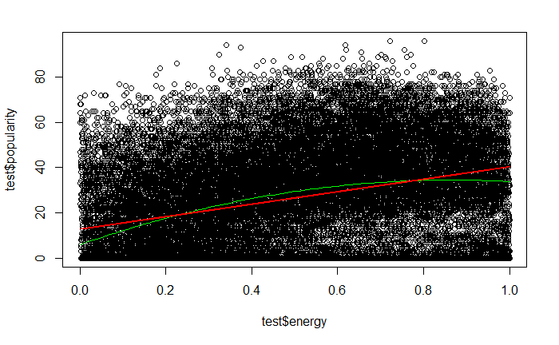

```r
lines(test$energy, energyPredict, col='red')
```

Zelena čiara kvadratický model má chybu 20.48 a červený lineárny model 20.65. Oba modely predikujú v najhustejšie osadenom priestore, no ako môžeme vidieť kvadratický model viac kopíruje tvar dát čo sa ukázalo aj na jeho nižšej chybe. Data sú pravdepodobne príliš rozptýlené aby sa mohol model lepšie nafitovať.

```r
acousticnessValues <- seq(0, 1, 0.01)

acousticnessQPredict <- predict(modelQPopAc,newdata = list(acousticness=acousticnessValues, acousticness2 = acousticnessValues^2))

acousticnessPredict <- predict(modelPopAc,newdata = test)

plot(test$acousticness, test$popularity)

lines(acousticnessValues, acousticnessQPredict, col='green')
```

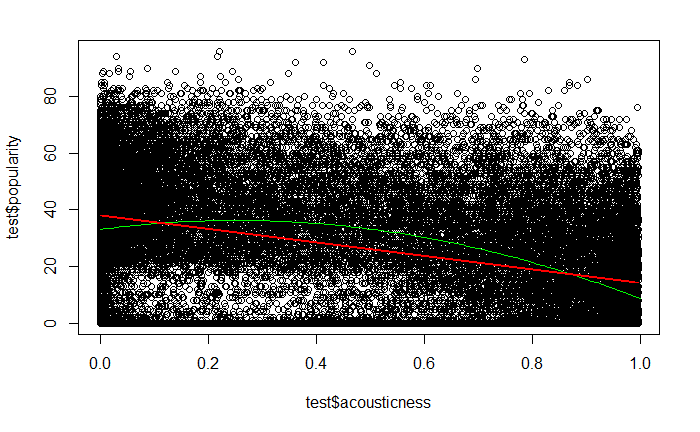

```r
lines(test$acousticness, acousticnessPredict, col='red')
```

Zelena čiara kvadratický model má chybu 19.54 a červený lineárny model 20.02. Oba modely predikujú v najhustejšie osadenom priestore, no ako môžeme vidieť kvadratický model viac kopíruje tvar dát čo sa znovu ukázalo aj na jeho nižšej chybe.

```r
loudnessValues <- seq(min(test$loudness), max(test$loudness), 0.01)

loudnessQPredict <- predict(modelQPopLo,newdata = list(loudness=loudnessValues, loudness2 = loudnessValues^2))

loudnessPredict <- predict(modelPopLo,newdata = test)

plot(test$loudness, test$popularity)

lines(loudnessValues, loudnessQPredict, col='green')
```

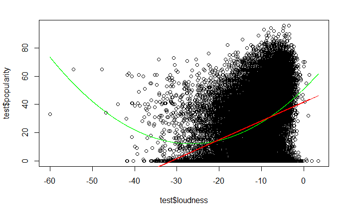

```r
lines(test$loudness, loudnessPredict, col='red')
```

Zelena krivka kvadratický model má chybu 20.44 a červený lineárny model 20.62. Lineárny model podľa grafu vyzerá tento krát lepšie no kvadratický mal aj napriek tomu nižšiu chybu čo je zrejme zapríčinené zhodou aj v riedkých datach v ľavej polovici grafu.

```r
instrumentalnessValues <- seq(min(test$instrumentalness), max(test$instrumentalness), 0.01)

instrumentalnessQPredict <- predict(modelQPopIns,newdata = list(instrumentalness=instrumentalnessValues, instrumentalness2 = instrumentalnessValues^2))

instrumentalnessPredict <- predict(modelPopIns,newdata = test)

plot(test$instrumentalness, test$popularity)

lines(instrumentalnessValues, instrumentalnessQPredict, col='green')
```

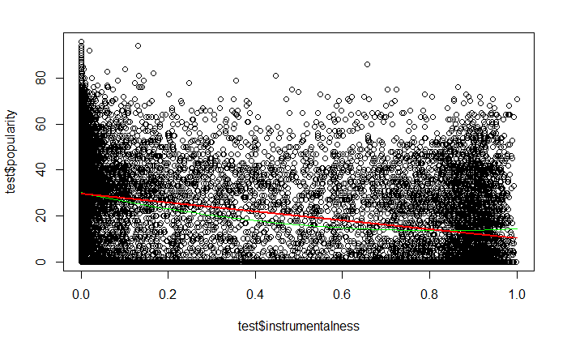

```r
lines(test$instrumentalness, instrumentalnessPredict, col='red')
```

Zelena krivka kvadratický model má chybu 20.99 a červený lineárny model 21.03. Pri tomto grafe môžeme vidieť, že dátam nevyhovuje ani jeden z modelov a majú aj vyššiu chybu oproti ostatným. Zrejme by bola vhodnejšia regresia zložitejšou funkciou.

BAYES

```r
#install.packages("R2OpenBUGS")
#install.packages("rjags")
#install.packages("coda")
#install.packages("MCMCvis")
library(R2OpenBUGS)
library(rjags)
library(coda)
library(MCMCvis)
mod = function(){
  #priors
  b0~dnorm(0,.001)
  Z~dnorm(0,.001)

  sigma~dunif(0,100)
  tau<-1/(sigma*sigma)


  #likelihood
  for(i in 1:length(energy)){
    mu[i]<-b0+100*exp(-Z*energy[i])
    Pop[i]~dnorm(mu[i], tau)
    Pop_pred[i]~dnorm(mu[i], tau)
  }

}
```

```r
# write model
model.file="model.txt"
write.model(mod,model.file)

# no initial values
inits<-NULL

# what parameters we want to track
params = c("tau","Z", "b0", "Pop_pred")

## hyperparameters
# number of iterations
ni = 1000
# burn in interval
nb = 100
# thinning interval
nt = 1
# number of chains
nc = 3

dataBay <- subset(test, select = c("popularity","energy"))[sample(nrow(test), 5000),]

# compile model
jmod = jags.model(file = model.file, data = dataBay, n.chains = nc, inits = inits, n.adapt = 1000)

# iterate through jmod for the extent of the burn-in
update(jmod, n.iter=nb, by=1)

# draw samples from the posterior for params, given MCMC hyperparameters
post = coda.samples(jmod, params, n.iter = ni, thin = nt)

# diagnostic evaluation of posterior samples
MCMCtrace(post, params = c('b0','Z'), pdf=F)

# objectively assess convergence with gelmans diagnostic
#gelman.diag(post)

# get summary of posterior samples for two parameters
MCMCsummary(post, params = c('b0','Z'), digits=2)
```

[output not shown]

```r
# get samples from posteriors
samples = jags.samples(jmod,c('b0', 'Z', 'Pop_pred'), length(dataBay$energy))
```

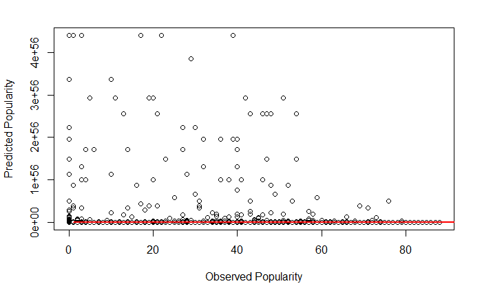

```r
# take the mean of each group of samples
posterior_means = apply(samples$Pop_pred,1,mean)

# plot posterior means versus observed values
plot(dataBay$popularity, posterior_means, ylab='Predicted Popularity', xlab='Observed Popularity')
lines(seq(1,3500),seq(1,3500), col='red', lwd=2, cex=3)
```

Predikcia pomocou bayesa sa nám nevydarila, vznikli nám hodnody veľmi vzdialené od reálnych hodnôt(>4e+56).